# Elegans: DE analysis

Lieven Clement

27 October 2019

# Contents

After fertilization but prior to the onset of zygotic transcription, the C. elegans zygote cleaves asymmetrically to create the anterior AB and posterior P1 blastomeres, each of which goes on to generate distinct cell lineages. To understand how patterns of RNA inheritance and abundance arise after this first asymmetric cell division, we pooled hand-dissected AB and P1 blastomeres and performed RNA-seq. http://www.ncbi.nlm.nih.gov/geo/query/acc.cgi?acc=GSE59943

The reads have been aligned to the genome and summarized to gene level in the Rsubread tutorial.

```r
library(edgeR)
```

# 1 Read featurecounts object

We import the featurecounts object that we have stored.

```r
fc <- readRDS("fcElegans.rds")
names(fc)
```

```
## [1] "counts"     "annotation" "targets"    "stat"
```

```r
counts_featurecounts <- fc$counts
head(counts_featurecounts)
```

```
##                SRR1532959.bam SRR1532960.bam SRR1532961.bam SRR1532962.bam
## WBGene00197333              0              0              0              0
## WBGene00198386              0              0              0              0
## WBGene00015153              0              0              0              0
## WBGene00002061            152            253            157             95
## WBGene00255704              0              0              0              0
## WBGene00235314              0              0              0              0
##                SRR1532963.bam SRR1532964.bam
## WBGene00197333              0              0
## WBGene00198386              0              0
## WBGene00015153              1              2
## WBGene00002061            144            152
## WBGene00255704              0              0
## WBGene00235314              0              0
```

```r
dim(counts_featurecounts)
```

```
## [1] 46904     6
```

```r
fc$stat
```

```
##                           Status SRR1532959.bam SRR1532960.bam
## 1                       Assigned        1657500        1323934
## 2            Unassigned_Unmapped          98398         257946
## 3           Unassigned_Read_Type              0              0
## 4           Unassigned_Singleton              0              0
## 5      Unassigned_MappingQuality              0              0
## 6             Unassigned_Chimera              0              0
## 7      Unassigned_FragmentLength              0              0
## 8           Unassigned_Duplicate              0              0
## 9        Unassigned_MultiMapping              0              0
## 10          Unassigned_Secondary              0              0
## 11           Unassigned_NonSplit              0              0
## 12         Unassigned_NoFeatures           9430          11104
## 13 Unassigned_Overlapping_Length              0              0
## 14          Unassigned_Ambiguity          18542          17985
##    SRR1532961.bam SRR1532962.bam SRR1532963.bam SRR1532964.bam
## 1         2013110        1304759        2568046        2208253
## 2           67401          82920         108861          92578
## 3               0              0              0              0
## 4               0              0              0              0
## 5               0              0              0              0
## 6               0              0              0              0
## 7               0              0              0              0
## 8               0              0              0              0
## 9               0              0              0              0
## 10              0              0              0              0
## 11              0              0              0              0
## 12          10279           5867          11931           9791
## 13              0              0              0              0
## 14          26523          16467          47238          27401
```

## 1.1 Read Meta Data

```r
target<-readRDS("elegansMetaData.rds")
```

# 2 Data Analysis

## 2.1 Setup count object edgeR

```r
dge<-DGEList(fc$counts)
substr(colnames(dge),1,10)==target$Run
```

```
## [1] TRUE TRUE TRUE TRUE TRUE TRUE
```

Order of information in target file and count table is the same

```r
colnames(dge)<-paste0(target$`cell type:ch1`,target$`replicate:ch1`)
cellType<-as.factor(target$`cell type:ch1`)
```

## 2.2 Normalisation

```r
dge<-calcNormFactors(dge)
```

## 2.3 Data exploration

One way to reduce dimensionality is the use of multidimensional scaling (MDS). For MDS, we first have to calculate all pairwise distances between our objects (samples in this case), and then create a (typically) two-dimensional representation where these pre-calculated distances are represented as accurately as possible. This means that depending on how the pairwise sample distances are defined, the two-dimensional plot can be very different, and it is important to choose a distance that is suitable for the type of data at hand.

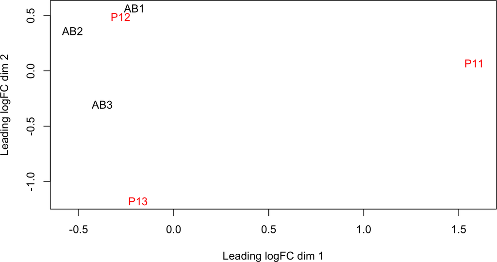

```r
plotMDS(dge, top = 500,col=as.double(cellType))
```

## 2.4 Differential analysis

### 2.4.1 Filtering

```r
design<-model.matrix(~cellType)
keep <- filterByExpr(dge, design)
dge <- dge[keep, ,keep.lib.sizes=FALSE]
```

The option keep.lib.sizes=FALSE causes the library sizes to be recomputed after the filtering. This is generally recommended, although the effect on the downstream analysis is usually small.

The normalisation factors have to be recalculated upon filtering.

```r
dge<-calcNormFactors(dge)
```

### 2.4.2 Model

We first estimate the overdispersion.

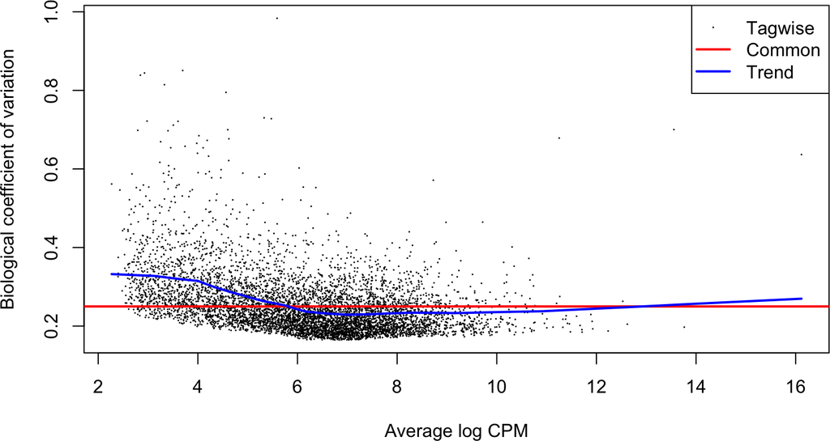

```r
dge <- estimateDisp(dge, design)
plotBCV(dge)
```

Finally, we fit the generalized linear model and perform the test. In the glmLRT function, we indicate which coefficient (which column in the design matrix) that we would like to test for. It is possible to test more general contrasts as well, and the user guide contains many examples on how to do this. The topTags function extracts the top-ranked genes. You can indicate the adjusted p-value cutoff, and/or the number of genes to keep.

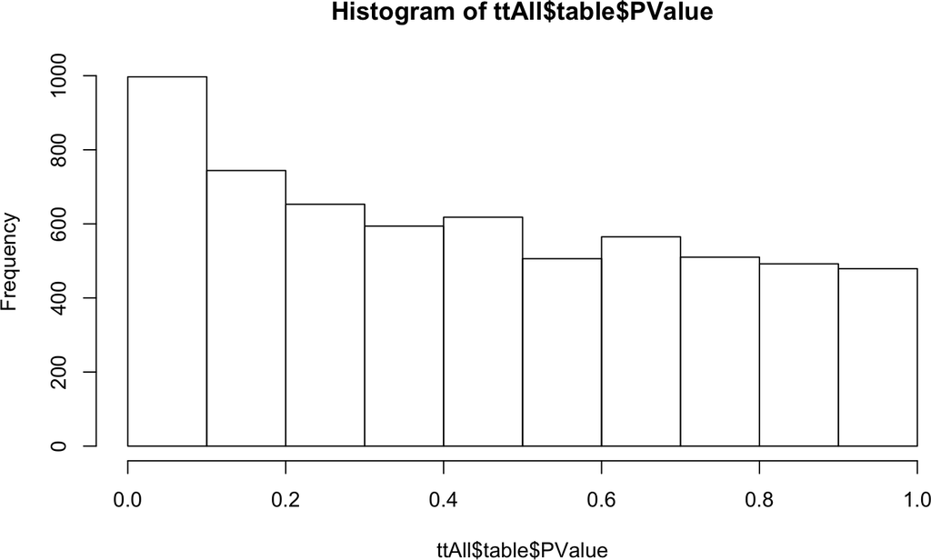

```r
fit <- glmFit(dge, design)
lrt <- glmLRT(fit, coef = ncol(design))
ttAll <-topTags(lrt, n = nrow(dge)) # all genes
hist(ttAll$table$PValue)
```

```r
tt <- topTags(lrt, n = nrow(dge), p.value = 0.05) # genes with adj.p<0.05
tt
```

```
## Coefficient:  cellTypeP1
##                     logFC    logCPM       LR       PValue          FDR
## WBGene00011409  2.3051280  7.119802 73.05792 1.259006e-17 7.752958e-14
## WBGene00017985 -1.7957089  7.372791 62.01882 3.401907e-15 1.047447e-11
## WBGene00016824 -1.8923338  6.753206 60.58811 7.035757e-15 1.444206e-11
## WBGene00019811  1.8317181  6.588456 48.07969 4.092443e-12 6.300316e-09
## WBGene00000388 -1.5819410  7.523366 45.20634 1.773298e-11 2.183993e-08
## WBGene00020948 -1.4293678  9.866419 44.42801 2.638848e-11 2.399019e-08
## WBGene00000496  2.5765059  6.137689 44.36365 2.727043e-11 2.399019e-08
## WBGene00021200  2.8405675  5.752301 43.29921 4.697733e-11 3.616080e-08
## WBGene00017397  1.8053895  4.954892 39.44648 3.371751e-10 2.307027e-07
## WBGene00010354  3.5189772  3.594563 36.90842 1.238099e-09 7.624211e-07
## WBGene00021009 -2.5009414  5.901792 35.03340 3.240984e-09 1.814362e-06
## WBGene00008823 -1.4590401  6.893432 33.67495 6.513416e-09 3.342468e-06
## WBGene00009035  2.4812880  3.637571 33.33107 7.773078e-09 3.682047e-06
## WBGene00008080 -1.5849757  6.273693 31.88531 1.635490e-08 7.193819e-06
## WBGene00000863 -1.3206086  6.869690 31.18917 2.340683e-08 9.609285e-06
## WBGene00009264  1.3101438  7.737531 29.98508 4.353831e-08 1.675681e-05
## WBGene00019001  1.5310735  5.796877 29.80333 4.781688e-08 1.732096e-05
## WBGene00009793 -1.5448441  6.443390 28.72037 8.361950e-08 2.860716e-05
## WBGene00016823 -1.6283682  6.822229 28.52248 9.261680e-08 3.001759e-05
## WBGene00009606 -1.6836921  7.018377 27.59933 1.492302e-07 4.221610e-05
## WBGene00006562  1.2334479  8.237130 27.59138 1.498448e-07 4.221610e-05
## WBGene00004374  1.3126857  8.205130 27.57883 1.508208e-07 4.221610e-05
## WBGene00018009 -1.1679161  7.288469 27.24427 1.793061e-07 4.800725e-05
## WBGene00009921 -1.4520825  7.509272 27.08123 1.950830e-07 5.005505e-05
## WBGene00005022  3.0989396  3.072409 26.65312 2.434579e-07 5.996854e-05
## WBGene00012031  1.6710488  5.983430 26.46157 2.688333e-07 6.367214e-05
## WBGene00007145  1.3911358  5.955030 26.23073 3.029626e-07 6.909791e-05
## WBGene00000550  1.8567741  6.986777 25.65848 4.075003e-07 8.692874e-05
## WBGene00008464 -1.3691265  6.098891 25.59697 4.206987e-07 8.692874e-05
## WBGene00002276 -1.7151651  7.783958 25.58421 4.234917e-07 8.692874e-05
## WBGene00020721  1.1766318  6.785538 25.31562 4.867513e-07 9.669080e-05
## WBGene00001333 -2.1906933  6.816367 25.20089 5.165825e-07 9.940984e-05
## WBGene00015463  1.1298098  7.473493 23.97879 9.740292e-07 1.817598e-04
## WBGene00004258  1.1255996  7.206061 23.83100 1.051748e-06 1.904901e-04
## WBGene00015515  1.4428044  4.813602 23.46583 1.271522e-06 2.237152e-04
## WBGene00020375 -1.1448080  9.964018 23.25288 1.420377e-06 2.429634e-04
## WBGene00001402  1.3805811  5.396251 22.72596 1.868267e-06 3.105851e-04
## WBGene00003994  1.1635326  7.673470 22.67691 1.916569e-06 3.105851e-04
```

[output cut: 58 more lines]

```
## WBGene00011225  1.8970620  3.966269 12.11100 5.012535e-04 3.182184e-02
## WBGene00003026  1.4137142  4.879505 12.05388 5.168481e-04 3.224261e-02
## WBGene00013529 -0.8337794  6.423924 12.04846 5.183532e-04 3.224261e-02
## WBGene00011272 -0.9044026  6.470998 11.95771 5.442162e-04 3.351283e-02
## WBGene00017951 -0.8492104  8.086304 11.84378 5.785435e-04 3.527397e-02
## WBGene00013339  0.8364854  6.384116 11.80672 5.901719e-04 3.563018e-02
## WBGene00020549  0.8701194  7.354495 11.65816 6.392142e-04 3.821632e-02
## WBGene00002804  1.0513295  5.504499 11.59312 6.619628e-04 3.919583e-02
## WBGene00004272  0.8604911  7.606023 11.57305 6.691470e-04 3.924388e-02
## WBGene00011986  1.1433862  6.271676 11.48880 7.001667e-04 4.060516e-02
## WBGene00018226  1.3684392  3.741883 11.47458 7.055460e-04 4.060516e-02
## WBGene00019341 -0.7131633  6.992116 11.31288 7.697138e-04 4.388794e-02
## WBGene00016632 -0.7425463  6.955333 11.22841 8.055457e-04 4.550964e-02
## WBGene00015102  1.1349527 10.206572 11.12247 8.528824e-04 4.774591e-02
## WBGene00004445  1.0439088  6.327324 11.05683 8.836111e-04 4.902052e-02
```

### 2.4.3 Plots

We first make a volcanoplot and an MA plot.

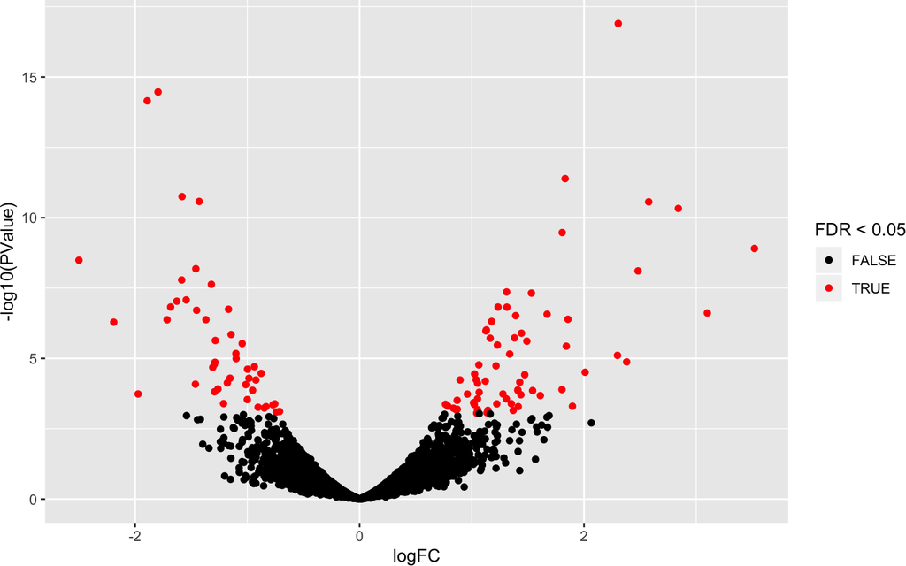

```r
library(ggplot2)
volcano<- ggplot(ttAll$table,aes(x=logFC,y=-log10(PValue),color=FDR<0.05)) + geom_point() + scale_color_manual(values=c("black","red"))
volcano
```

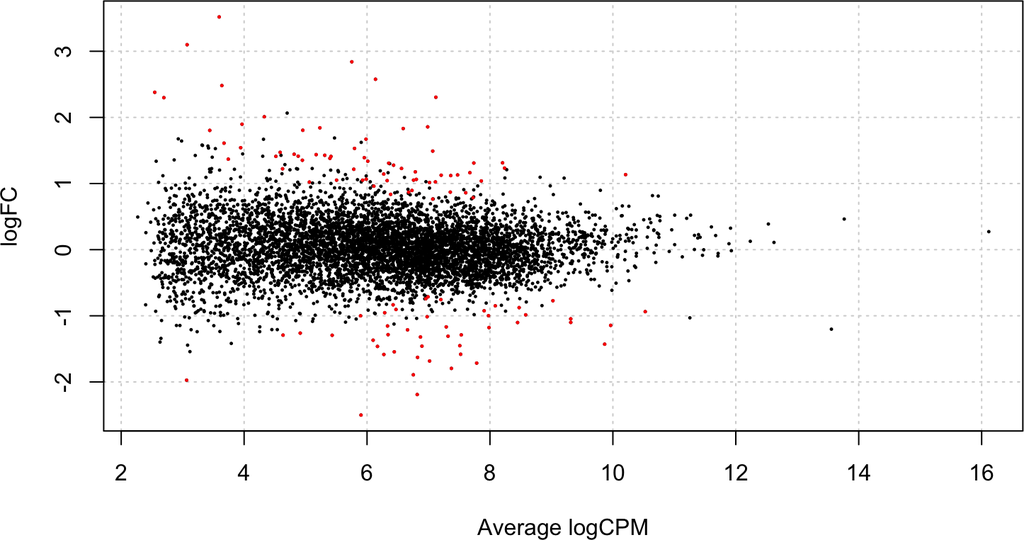

```r
plotSmear(lrt, de.tags = row.names(tt$table))
```

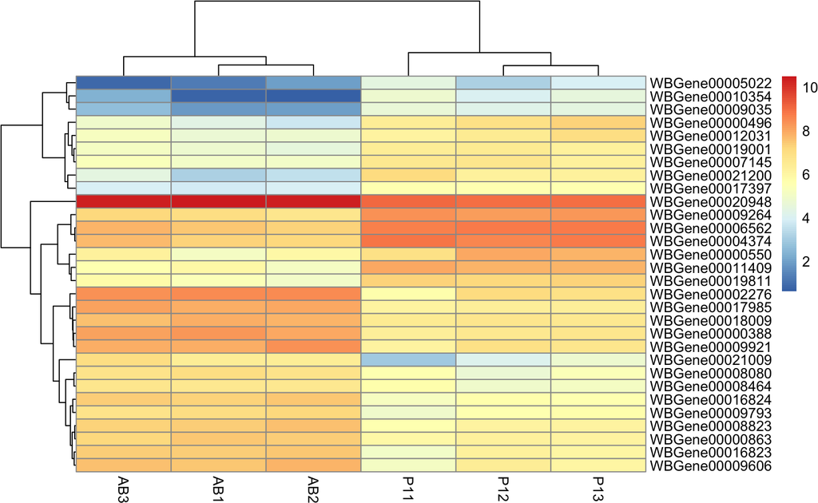

```r
library(pheatmap)
pheatmap(cpm(dge,log=TRUE)[rownames(tt$table)[1:30],])
```